# Final Report: Recovery and synchronized management of fisheries

Seleni Cruz and Juliette Verstean

June 3, 2019

Selecting generalist redator and prey For the simulations we used general predator and prey charactieristics, as used in Samhouri et al. (2017) (Table 1).

List of parameters for predator-prey model

| Varible | Description | Values | Units |
| --- | --- | --- | --- |
| P | Predator | 50 | # individuals |
| X | Focal prey | 30 | # individuals |
| Y | Non-dynamic prey | 500 | # individuals |
| rx | Growth rate prey | 1 | y^-1 |
| dp | Predator mortality rate | 0.25 | y^-1 |
| kp | Predator carrying capacity | 25 | # individuals |
| kx | Prey carrying capacity | 100 | # individuals |
| ax | Predation rate on focal prey | 0.03 | # individuals^-1*y^-1 |
| ay | Predation rate on non-dynamic prey | 0.03 | # individuals^-1*y^-1 |
| hp | Predator harvest rate | 0.325 | y^-1 |
| hx | Focal prey harvest rate | 0.65 | y^-1 |
| c | Predator conversion rate of prey | 0.05 | prey/predator |

Simulating trophic downgrading

We used the predator prey and the wrapper function to first simulate trophic downgrading (Figure 1). Three steps included: 1. Using initial predator and prey populations (X0 and P0) we ran the model to equilibrium for the first 30 timesteps 2. After equilibrium, we began harvesting the predator first. Simulating a scenario where fishers would first target these fisheries. 3. After the population has been depleted, we simulated harvesting the prey.

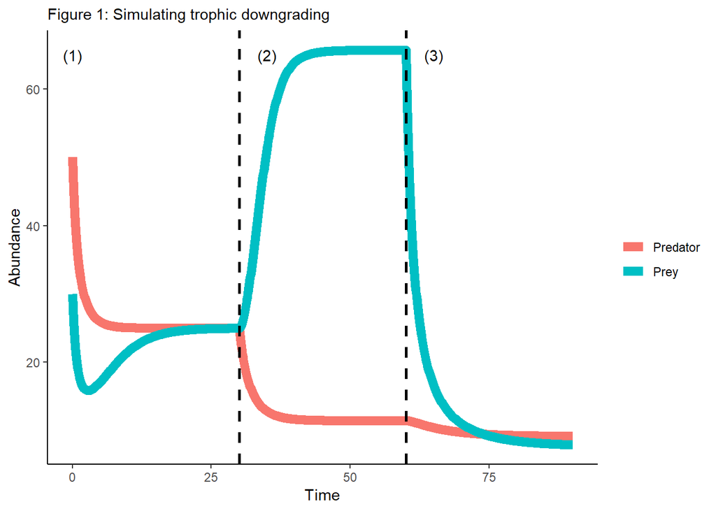

First management interventon: first removing harvesting from predator and then prey

After simulating trophic downgrading we simulated single species management interventions, protection of predator first and then prey (Figure 2).

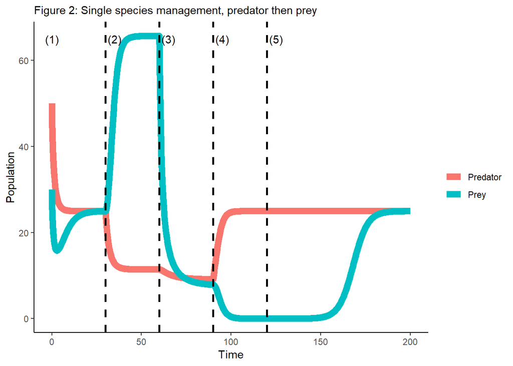

Second management interventon: first removing harvesting from prey and then predator

The second management scenrio simulated the protection of prey first and then predator (Figure 3).

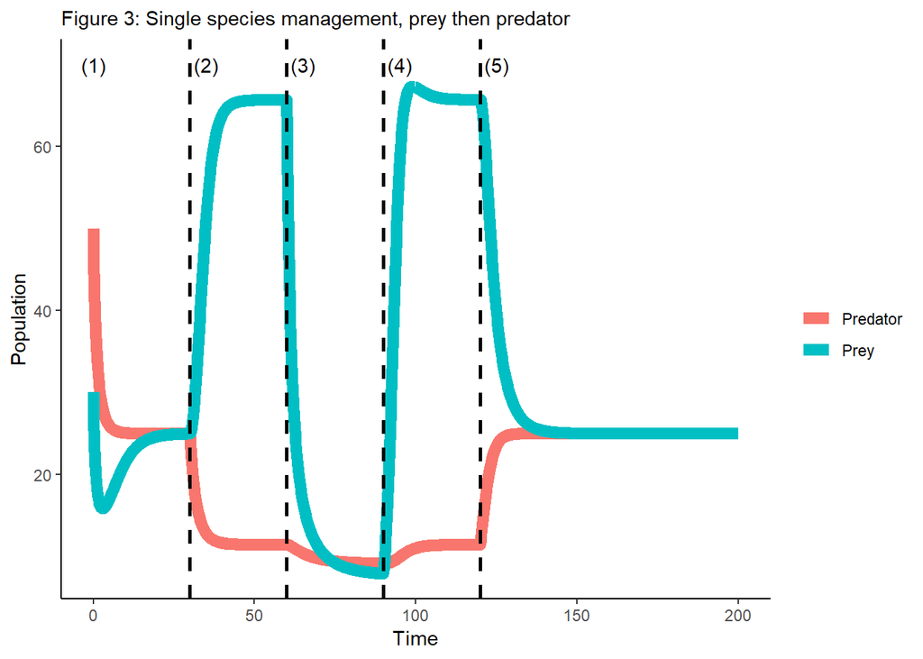

Third management intervention: simulating syncronized closure to both predator and prey

We simulated combined closures in the form of marine proteted areas (MPAs) by removing harvesting. For example a marine protected area that covers 50% of the area is simulated by removing 50% of the haverst rate for both predator and prey. While we initally wanted to make this part of the model spatial, area represented by a series of vectors) we were not able to do so using ODE since inital values of ODE cannot be vectors but rather single values.

MPAs were simulated from 0 to 100% in 10% increments. Figure 4 and 5 present 50% and 100% closures, respectively.

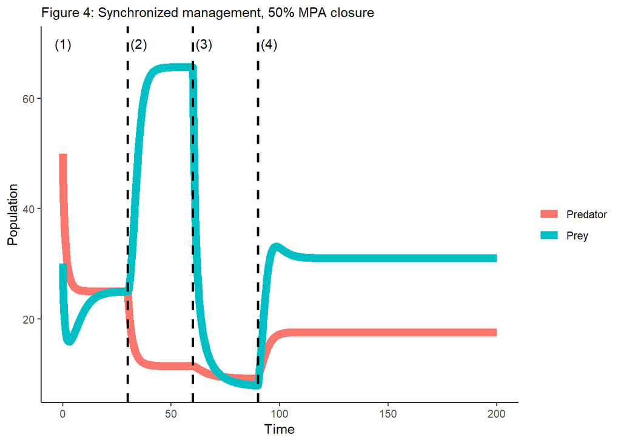

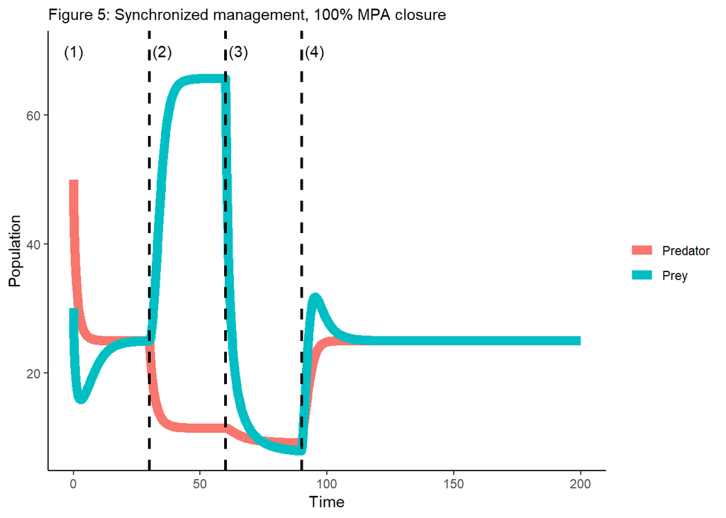

Comparison of scenarios

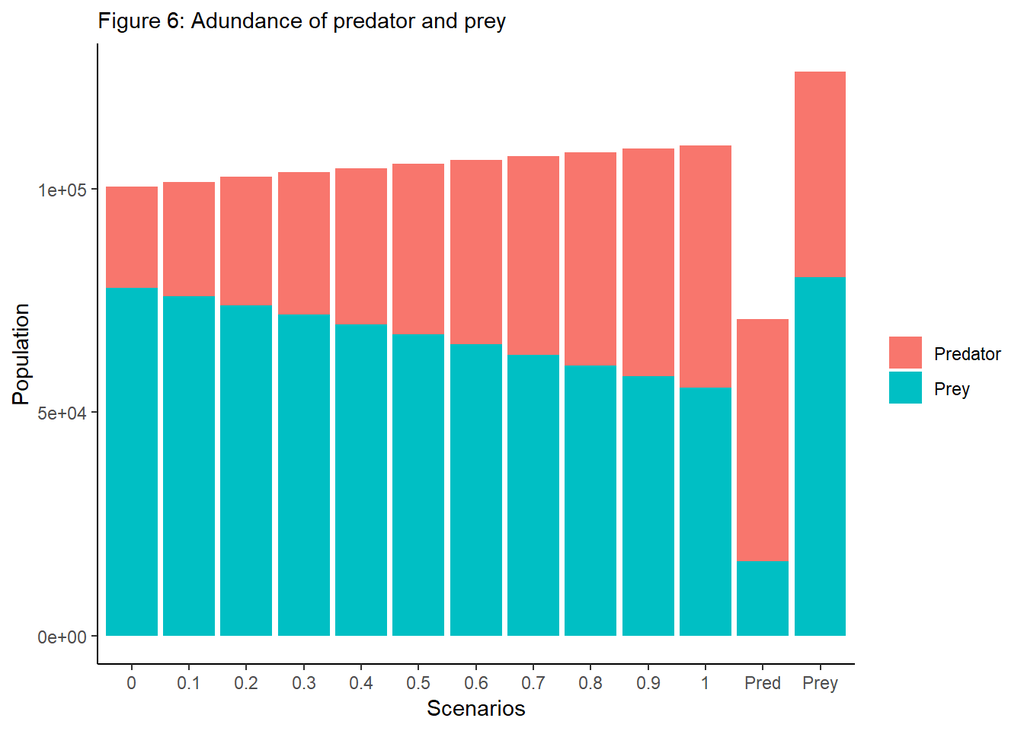

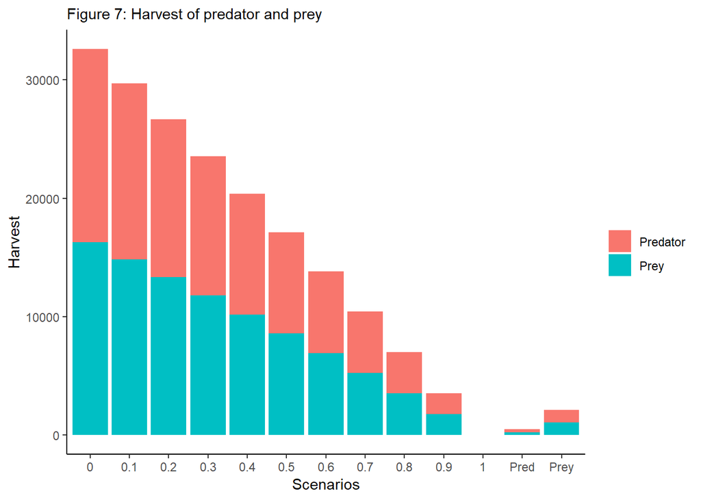

Sensitivity

We also conduted sensitivity analysis of the model parameters using Sobol for management scenario 1. When we ran the analyis with all variables, the model was most sensitive to initial population of both predator and prey (X0 and P0). When we removed these variables to test for sesnitivity for other parameters, Sobol returned NAN values.

```
##     original
## hx  0.000000
## hp  0.000000
## c   0.000000
## rx  0.000000
## dp  0.000000
## X0 -4.740804
## P0  1.231478
## ax  0.000000
## ay  0.000000
## Kx  0.000000
## Kp  0.000000
## Y   0.000000
```

```
##     original
## hx 0.0000000
## hp 0.0000000
## c  0.0000000
## rx 0.0000000
## dp 0.0000000
## X0 5.6360627
## P0 0.1153155
## ax 0.0000000
## ay 0.0000000
## Kx 0.0000000
## Kp 0.0000000
## Y  0.0000000
```

```
##     original
## hx  0.000000
## hp  0.000000
## c   0.000000
## rx  0.000000
## dp  0.000000
## X0  1.199015
## P0 -2.233743
## ax  0.000000
## ay  0.000000
## Kx  0.000000
## Kp  0.000000
## Y   0.000000
```

```
##     original
## hx  0.000000
## hp  0.000000
## c   0.000000
## rx  0.000000
## dp  0.000000
## X0 -1.191831
## P0  4.186904
## ax  0.000000
## ay  0.000000
## Kx  0.000000
## Kp  0.000000
## Y   0.000000
```

```
##    original
## hx      NaN
## hp      NaN
## c       NaN
## rx      NaN
## dp      NaN
## ax      NaN
## ay      NaN
```

```
##    original
## hx      NaN
## hp      NaN
## c       NaN
## rx      NaN
## dp      NaN
## ax      NaN
## ay      NaN
```

```
##    original
## hx      NaN
## hp      NaN
## c       NaN
## rx      NaN
## dp      NaN
## ax      NaN
## ay      NaN
```

```
##    original
## hx      NaN
## hp      NaN
## c       NaN
## rx      NaN
## dp      NaN
## ax      NaN
## ay      NaN
```

Key take aways 1. Predator first then prey recovery is still widely used in fisheries management. 2. Our results show that in some cases this is the least optimal management intervention to achieve fisheries productivity. 3. Implementation of syncronized closures can outperform other intervnetions, although there are several factors to consider that are not included in this short analysis.

Samhouri, Jameal F., Adrian C. Stier, Shannon M. Hennessey, Mark Novak, Benjamin S. Halpern, and Phillip S. Levin. 2017. “Rapid and Direct Recoveries of Predators and Prey Through Synchronized Ecosystem Management.” *Nature Ecology & Evolution* 1 (4): 0068. https://doi.org/10.1038/s41559-016-0068.